# Network Analysis Using R

Martin Schweinberger

2019-12-12

# 1 Introduction

This document is the report for the *Network Analysis Using R* workshop at QUT, Brisbane, 20121212.

Networks, or graphs, consist of nodes (typically represented as dots) and edges (typically represented as lines) and they can be directed or undirected networks. In directed networks, the direction of edges is captured. For instance, the exports of countries. In such cases the lines are directed and typically have arrows to indicate direction. The thinkness of lines can also be ustilized to encode information such as frequency of contact.

Networks can have different layouts.

The *centrality of networks* is measured as * Node degree * Node closeness (the closer two nodes are, the closer connected ethy are) * Node betweeness * Edge betweenness

There are two ways to capture the basic structure of a network * Adjacency matrix (Matrix of 0s and 1s depending on whether the nodes are connected or not)

```
##   A B C D E F G
## A 0 1 1 1 1 1 0
## B 1 0 0 0 0 0 0
## C 1 0 0 0 0 0 0
## D 1 0 0 0 0 0 0
## E 1 0 0 0 0 1 0
## F 1 0 0 0 1 0 1
## G 0 0 0 0 0 1 0
```

*Edge list (Two column matrix to indicate which nodes are connected)

```
##      V1  V2
## [1,] "A" "B"
## [2,] "A" "C"
## [3,] "A" "D"
## [4,] "A" "E"
## [5,] "A" "F"
## [6,] "E" "F"
## [7,] "F" "G"
```

The example that we will be concerned with is the Who is connected with whom on Twitter and who is the most cetral node in the network?

Outline of the workshop * Install R and R Studio * Import data from Australian Twittershere * Tidy data

# 2 Network Analysis in R Using the igraph package

We will now begin with the analysis. In a first step, the session is prepared by clearing the workspace, setting options, activating packages and functions, as well as loading relevant functions.

```r
# activate packages
library(dplyr)
library(igraph)
# import data
# Read in data from a .csv
replies <- read.csv("data/query1_results_anon.csv",
                    header = TRUE,
                    fileEncoding = "UTF-8-BOM")
# inspect data
head(replies)
```

```
##   original_tweet_tweet_id original_tweet_user_id reply_tweet_id reply_user_id
## 1                    t001                   u106           t005          u052
## 2                    t001                   u106           t115          u121
## 3                    t002                   u007           t011          u046
## 4                    t003                   u061           t006          u068
## 5                    t004                   u124           t013          u095
## 6                    t007                   u057           t008          u091
```

Take the data that was imported and create counts of the number of replies between users.

```r
# create edge list
reply_edges <- replies %>%
  group_by(original_tweet_user_id, reply_user_id) %>%
  summarise(nbr_replies = n())
# inspect edge list
head(reply_edges)
```

```
## # A tibble: 6 x 3
## # Groups:   original_tweet_user_id [5]
##   original_tweet_user_id reply_user_id nbr_replies
##   <fct>                  <fct>               <int>
## 1 u001                   u029                    1
## 2 u002                   u002                    1
## 3 u004                   u090                    1
## 4 u005                   u069                    1
## 5 u005                   u093                    1
## 6 u007                   u046                    1
```

View the results (number of replies between users) to make sure it looks OK. This will be used as input to create the igraph object and inspect the igraph object. The first number is the number of nodes and the second number is the number of edges.

```r
# create igraph object using an edge list: reply_edges
reply_g <- graph_from_data_frame(d = reply_edges, directed = TRUE)
# inspect igraph properties
reply_g
```

```
## IGRAPH cb68df5 DN-- 131 90 --
## + attr: name (v/c), nbr_replies (e/n)
## + edges from cb68df5 (vertex names):
##  [1] u001->u029 u002->u002 u004->u090 u005->u069 u005->u093 u007->u046
##  [7] u007->u060 u010->u097 u011->u005 u012->u087 u012->u105 u014->u055
## [13] u015->u056 u019->u005 u020->u074 u021->u033 u021->u104 u022->u113
## [19] u024->u117 u024->u118 u030->u035 u031->u079 u032->u076 u037->u071
## [25] u037->u076 u039->u018 u041->u101 u047->u008 u047->u013 u047->u025
## [31] u047->u103 u048->u075 u050->u050 u051->u114 u053->u003 u054->u023
## [37] u057->u034 u057->u091 u059->u028 u061->u068 u062->u069 u062->u108
## [43] u062->u111 u064->u064 u066->u040 u067->u016 u067->u067 u069->u005
## + ... omitted several edges
```

We will now plot the network diagram.

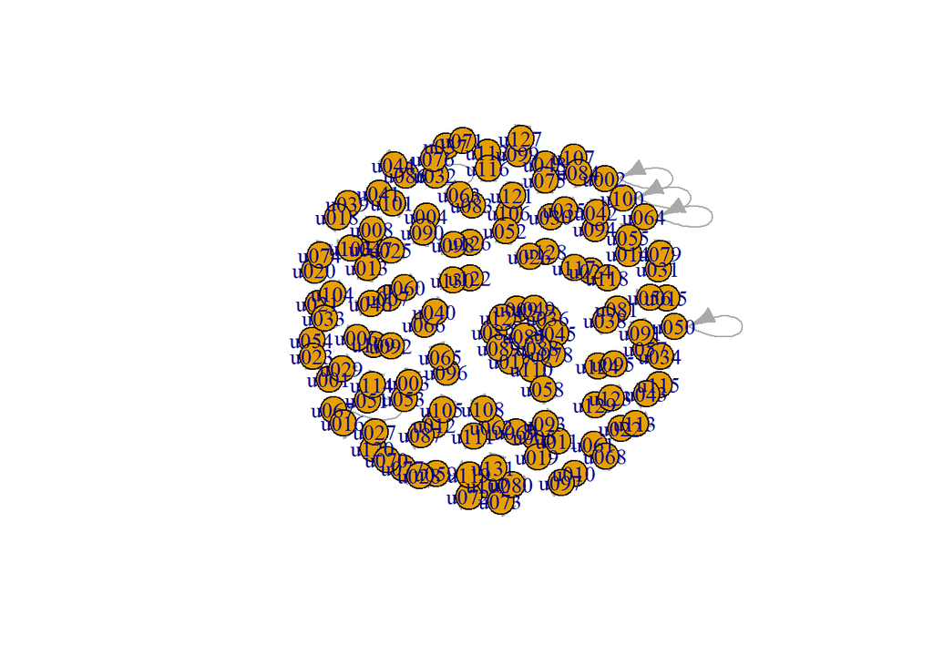

```r
# default plot settings
plot(reply_g)
```

That doesn’t look good! So let’s try removing the node (vertex) labels

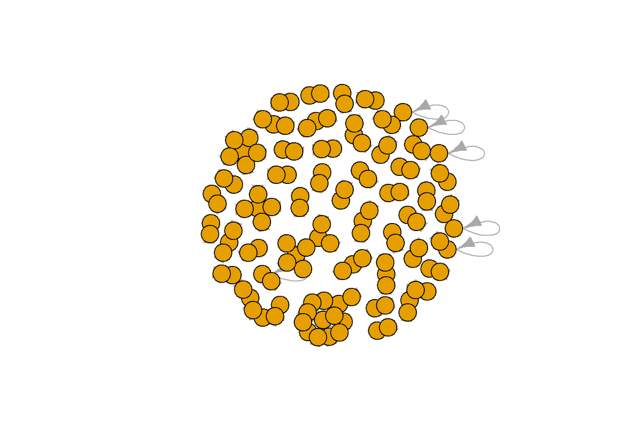

```r
plot(reply_g, vertex.label = NA)
```

This plot look better, but the nodes are obscuring the arrows which is why we isolate the reflexive nodes in the edge list.

```r
(reply_edges %>%
    filter(as.character(original_tweet_user_id)
        == as.character(reply_user_id)))
```

```
## # A tibble: 6 x 3
## # Groups:   original_tweet_user_id [6]
##   original_tweet_user_id reply_user_id nbr_replies
##   <fct>                  <fct>               <int>
## 1 u002                   u002                    1
## 2 u050                   u050                    1
## 3 u064                   u064                    1
## 4 u067                   u067                    2
## 5 u086                   u086                    2
## 6 u100                   u100                    1
```

If we have time, we will remove these later btu for now, we will just adjust the size and colour of the nodes.

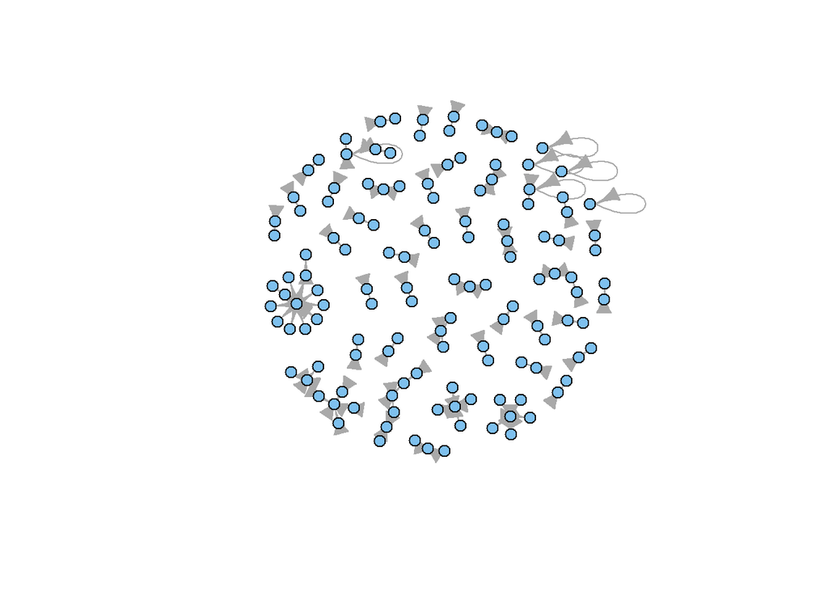

```r
plot(reply_g, vertex.label = NA,
     vertex.color = "SkyBlue2", vertex.size = 7)
```

Now we can see the arrows, but they need to be a little smaller which is why we adjust the arrow size.

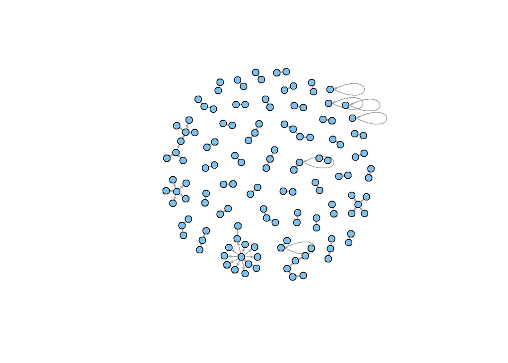

```r
plot(reply_g, vertex.label = NA,
     vertex.color = "SkyBlue2", vertex.size = 7,
     edge.arrow.size = 0.2)
```

We now adjust edge thicknessbut to do this, we first create a vector of edge weights based on number of replies and inspect the results.

```r
weight1 <- E(reply_g)$nbr_replies
# inspect results
head(weight1)
```

```
## [1] 1 1 1 1 1 1
```

We now plot the graph with the edge thickness determined by weights.

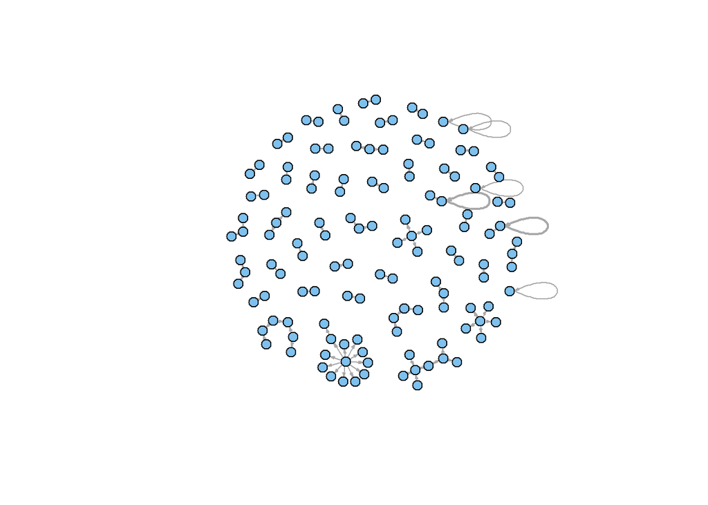

```r
plot(reply_g, vertex.label = NA,
     vertex.color = "SkyBlue2", vertex.size = 7,
     edge.arrow.size = 0.2, edge.width = weight1)
```

We are now in a position, where we can customize the layouts. The first layout is Kamada and Kawai layout (a type of radial layout).

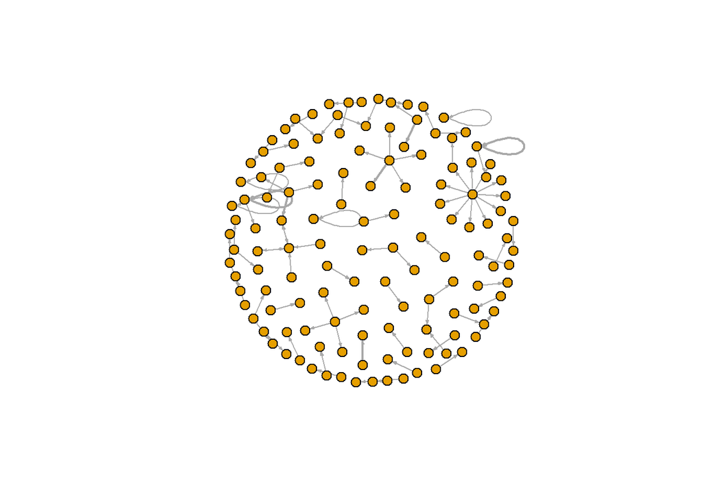

```r
plot(reply_g, vertex.label = NA,
     vertex.color = V(reply_g)$color, vertex.size = 7,
     edge.arrow.size = 0.2, edge.width = weight1,
     layout = layout.kamada.kawai)
```

The next layout is a circle layout.

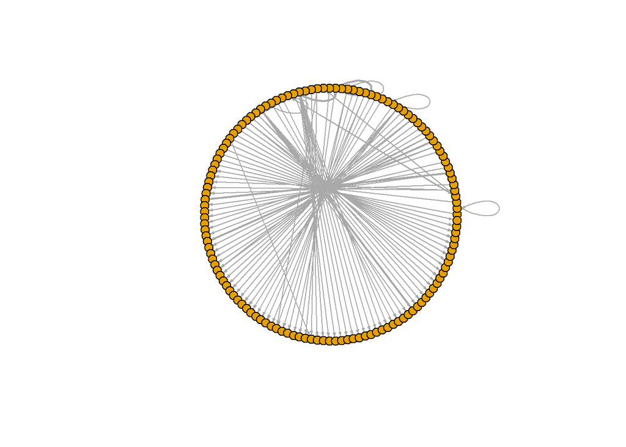

```r
plot(reply_g, vertex.label = NA,
     vertex.color = V(reply_g)$color, vertex.size = 7,
     edge.arrow.size = 0.2, edge.width = weight1,
     layout = layout.circle)
```

The next layout is a tree layout (dendogram).

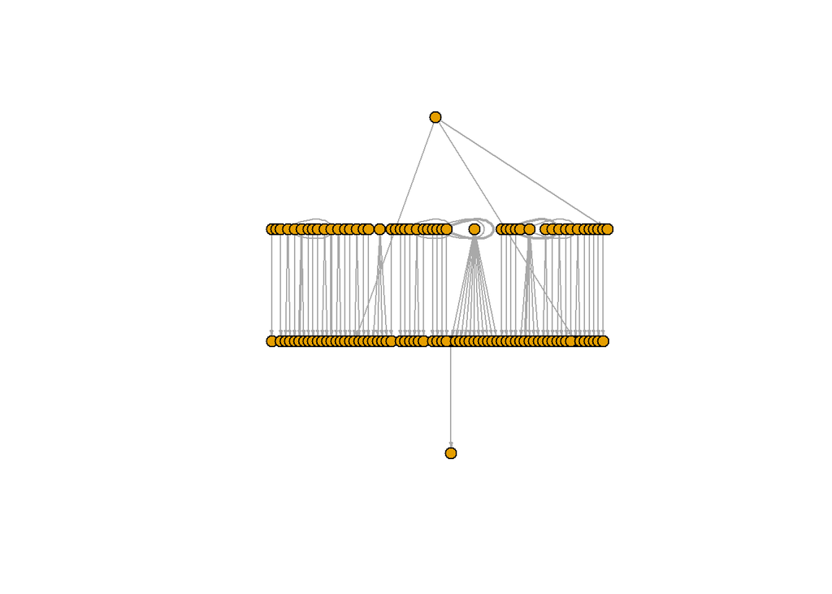

```r
plot(reply_g, vertex.label = NA,
     vertex.color = V(reply_g)$color, vertex.size = 7,
     edge.arrow.size = 0.2, edge.width = weight1,
     layout = layout.reingold.tilford)
```

We will now customize the layout and write layout nicely function but we first, save the results of the layout_nicely() function

```r
nice_layout <- layout_nicely(reply_g)
```

We can now plot the network diagram specifying your saved output

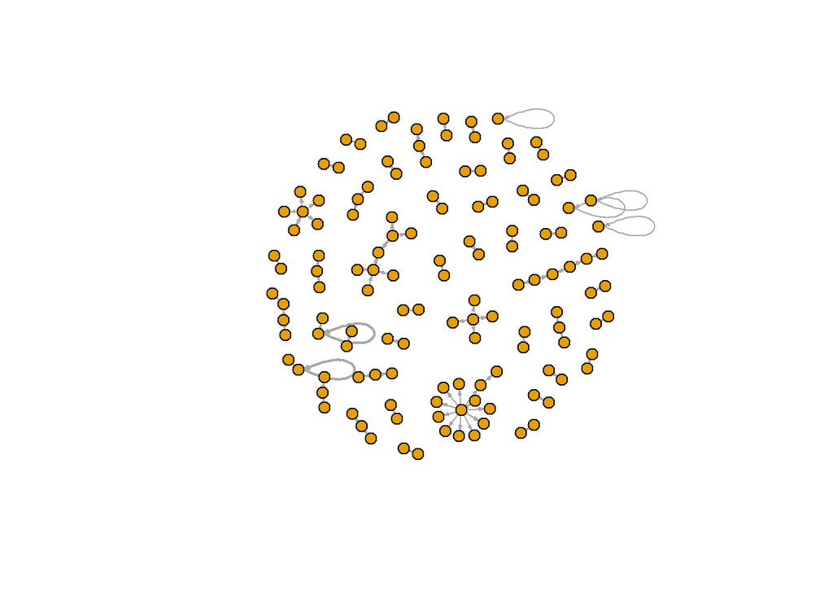

```r
plot(reply_g, vertex.label = NA,
     vertex.color = V(reply_g)$color, vertex.size = 7,
     edge.arrow.size = 0.2, edge.width = weight1,
     layout = nice_layout)
```

We will now check how to inspect the quantitative properties of networks. We start by extracting the node degree (total) from the igraph object and save it.

```r
reply_g_degree <- degree(reply_g)
```

Next, we turn it into an easy to read data frame and sort it in descending order by degree and inspect the results.

```r
reply_g_degree <- data.frame(user_id = names(reply_g_degree),
                             degree = reply_g_degree,
                             row.names = NULL) %>%
  arrange(desc(degree))

# inspect results
head(reply_g_degree)
```

```
##   user_id degree
## 1    u085     11
## 2    u005      6
## 3    u102      5
## 4    u047      4
## 5    u062      3
## 6    u067      3
```

Next, we check the *out degree* extract the out degree from the igraph object and save it.

```r
reply_g_degree_out <- degree(reply_g, mode = "out")
```

Next, we turn it into an easy to read data frame and sort it in descending order by degree and inspect the results.

```r
reply_g_degree_out <- data.frame(user_id = names(reply_g_degree_out),
                                 out_degree = reply_g_degree_out,
                                 row.names = NULL) %>%
  arrange(desc(out_degree))
# inspect results
head(reply_g_degree_out)
```

```
##   user_id out_degree
## 1    u085         11
## 2    u102          5
## 3    u047          4
## 4    u062          3
## 5    u005          2
## 6    u007          2
```

Next, we check the *in degree* and extract the in degree from the igraph object and save it.

```r
reply_g_degree_in <- degree(reply_g, mode = "in")
```

Next, turn it into an easy to read data frame and sort it in descending order by degree.

```r
reply_g_degree_in <- data.frame(user_id = names(reply_g_degree_in),
                                in_degree = reply_g_degree_in,
                                row.names = NULL) %>%
  arrange(desc(in_degree))
# inspect results
head(reply_g_degree_in)
```

```
##   user_id in_degree
## 1    u005         4
## 2    u069         2
## 3    u076         2
## 4    u028         2
## 5    u070         2
## 6    u002         1
```

Next, we use conditional colouring of nodes and highlight user “u085” who/which is the most central node.

```r
V(reply_g)$color <- ifelse(
  V(reply_g)$name == "u085", "red", "SkyBlue2"
)
```

Now, we replot the graph to show the results.

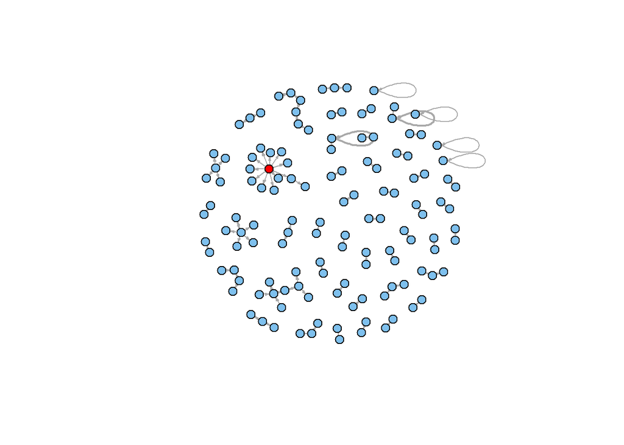

```r
plot(reply_g, vertex.label = NA,
     vertex.color = V(reply_g)$color, vertex.size = 7,
     edge.arrow.size = 0.2, edge.width = weight1)
```

Now, we be filtering nodes and edges and return to our earlier network diagram results.

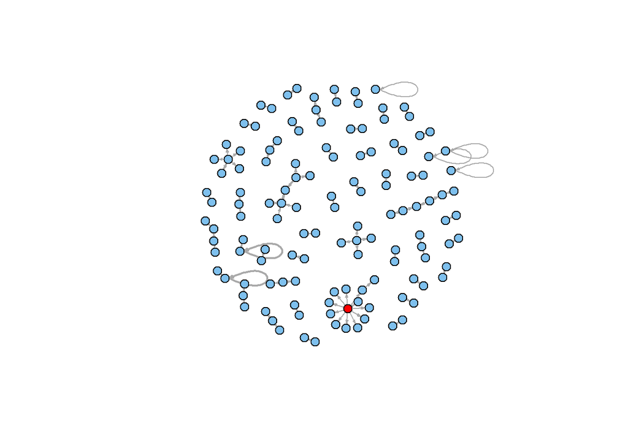

```r
plot(reply_g, vertex.label = NA,
     vertex.color = V(reply_g)$color, vertex.size = 7,
     edge.arrow.size = 0.2, edge.width = weight1,
     layout = nice_layout)
```

Recall that these are the accounts that have replied to themselves (reflexive nodes).

```r
(reply_edges %>%
    filter(as.character(original_tweet_user_id)
        == as.character(reply_user_id)))
```

```
## # A tibble: 6 x 3
## # Groups:   original_tweet_user_id [6]
##   original_tweet_user_id reply_user_id nbr_replies
##   <fct>                  <fct>               <int>
## 1 u002                   u002                    1
## 2 u050                   u050                    1
## 3 u064                   u064                    1
## 4 u067                   u067                    2
## 5 u086                   u086                    2
## 6 u100                   u100                    1
```

It turns out there is a very simple way to remove reflexive nodes in igraph: use the simplify function.

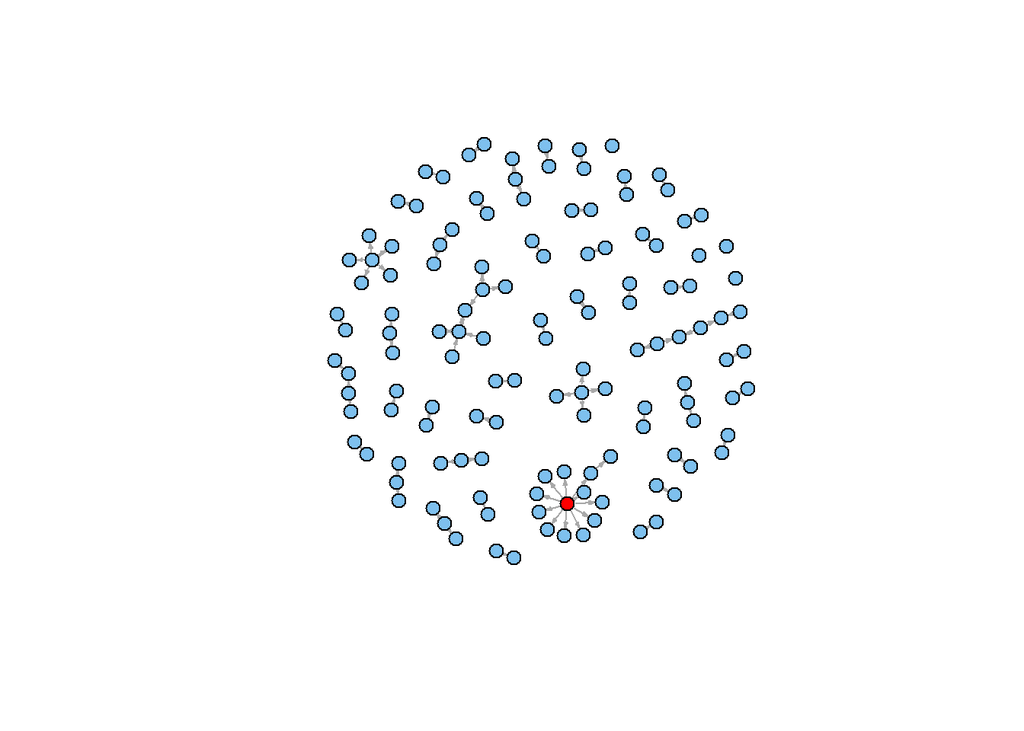

```r
reply_g2 <- simplify(reply_g, remove.loops = TRUE)
# plot the network diagram with reflexive edges removed
plot(reply_g2, vertex.label = NA,
     vertex.color = V(reply_g)$color, vertex.size = 7,
     edge.arrow.size = 0.2, edge.width = weight1,
     layout = nice_layout)
```

We have reached the end of our analysis.